# CHD1 R616Q/+ NPC RNA-seq analysis

Kimberley Jade Anderson

2026-06-26

# 1 Aim

This R Markdown contains the RNA-seq analysis for female mouse NPCs derived from wild-type and `Chd1R616Q/+` embryos. It includes only the analyses needed for the missense model gene-expression results in the manuscript, excluding the RNA-seq variant and mutational signature analyses.

The main outputs are:

- differential expression analysis for `Chd1+/+` vs `Chd1R616Q/+` NPCs under DMSO/control conditions;
- sample-level QC plots;
- p-value and FDRtool correction checks;
- export of differential expression tables;
- top p-value decile gene list for enrichment analysis;
- normalized expression plots for oxytocin pathway genes;
- gene-length analysis by p-value decile.

### 1.0.1 First QC

```bash
#Entering every folder and running fastqc on every pair of fastq files
find . -maxdepth 1 -mindepth 1 -type d -exec sh -c "cd '{}' &&
    pwd &&
    fastqc *.fq.gz -t 90  \;
```

### 1.0.2 Ran Kallisto on every file for pseudoalignment

```bash
#Script to run kallisto on everything
find . -maxdepth 1 -mindepth 1 -type d -exec sh -c "cd '{}' && pwd && kallisto quant -i /hpcdata/Mimir/kimberl/mm39_ncRNA_cDNA.idx -o '{$1}'_20230102_Kallisto -b 100 -t 48 *_1.fq.gz *_2.fq.gz" \;
```

### 1.0.3 Libraries

```r
library(DESeq2)
library(tximport)
library(TxDb.Mmusculus.UCSC.mm10.ensGene)
library(EnsDb.Mmusculus.v79)
library(ensembldb)
library(dplyr)
library(tidyr)
library(ggplot2)
library(kableExtra)
library(fdrtool)
library(pheatmap)
library(RColorBrewer)
library(GenomicRanges)
library(GeneOverlap)
```

# 2 Input files and sample metadata

This analysis assumes that Kallisto outputs are stored in one directory per sample, each containing an `abundance.h5` file.

Expected files:

- `Kallisto_files_CHD1_DHT/<sample>/abundance.h5`
- `samplesheet_final.csv`
- optional: `temp_mNPC_all_detected_genes_DEseq.csv`, for the unrelated RNA-seq dataset used in the gene-length comparison.

The sample sheet should contain at least:

- `samples`
- `treatment`
- `genotype`

For this missense model analysis, only DMSO/control samples are used.

## 2.1 Imported kallisto abundance files into R

```r
kallisto_dir <- "Kallisto_files_CHD1_DHT"
sample_sheet_file <- "samplesheet_final.csv"

sample.sheet <- read.csv(sample_sheet_file)

sample.sheet <- sample.sheet %>%
  mutate(
    embryo = substr(samples, start = 2, stop = 7),
    embryo = factor(embryo),
    genotype = factor(genotype),
    treatment = factor(treatment)
  )

sample.sheet.genotype <- sample.sheet %>%
  filter(treatment == "DMSO") %>%
  droplevels()

files.genotype <- file.path(kallisto_dir, sample.sheet.genotype$samples, "abundance.h5")
names(files.genotype) <- sample.sheet.genotype$samples

stopifnot(all(file.exists(files.genotype)))

sample.sheet.genotype
```

```
##                          samples treatment    genotype embryo
## 1 A1470_1_DMSO_20230102_Kallisto      DMSO Chd1+/R616Q 1470_1
## 2 A1470_3_DMSO_20230102_Kallisto      DMSO     Chd1+/+ 1470_3
## 3 A1470_4_DMSO_20230102_Kallisto      DMSO     Chd1+/+ 1470_4
## 4 A1470_5_DMSO_20230102_Kallisto      DMSO Chd1+/R616Q 1470_5
## 5 A2288_2_DMSO_20230102_Kallisto      DMSO Chd1+/R616Q 2288_2
## 6 A2288_5_DMSO_20230109_Kallisto      DMSO Chd1+/R616Q 2288_5
## 7 A2288_6_DMSO_20230102_Kallisto      DMSO     Chd1+/+ 2288_6
## 8 A2288_8_DMSO_20230109_Kallisto      DMSO     Chd1+/+ 2288_8
```

# 3 Transcript-to-gene annotation

```r
txdb <- TxDb.Mmusculus.UCSC.mm10.ensGene
transcript_ids <- ensembldb::keys(txdb, keytype = "TXNAME")
tx2gene <- ensembldb::select(txdb, transcript_ids, "GENEID", "TXNAME")
```

# 4 Import Kallisto abundance files

```r
txi.genotype <- tximport(
  files.genotype,
  type = "kallisto",
  tx2gene = tx2gene,
  ignoreTxVersion = TRUE
)
```

# 5 Differential expression analysis

The comparison is `Chd1+/+` vs `Chd1R616Q/+` in DMSO/control-treated female NPCs.

```r
dds.genotype <- DESeqDataSetFromTximport(
  txi.genotype,
  colData = sample.sheet.genotype,
  design = ~ genotype
)

keep <- rowSums(counts(dds.genotype)) >= 10
dds.genotype <- dds.genotype[keep, ]

dds.genotype$genotype <- relevel(dds.genotype$genotype, ref = "Chd1+/+")

dds.genotype <- DESeq(dds.genotype)
resultsNames(dds.genotype)
```

```
## [1] "Intercept"                       "genotype_Chd1..R616Q_vs_Chd1..."
```

```r
res.genotype <- results(dds.genotype)
summary(res.genotype)
```

```
##
## out of 18169 with nonzero total read count
## adjusted p-value < 0.1
## LFC > 0 (up)       : 12, 0.066%
## LFC < 0 (down)     : 7, 0.039%
## outliers [1]       : 19, 0.1%
## low counts [2]     : 0, 0%
## (mean count < 1)
## [1] see 'cooksCutoff' argument of ?results
## [2] see 'independentFiltering' argument of ?results
```

# 6 Annotate genes

```r
res.genotype <- as.data.frame(res.genotype)
res.genotype$gene_id <- rownames(res.genotype)

gene.annotation <- ensembldb::select(
  EnsDb.Mmusculus.v79,
  keys = res.genotype$gene_id,
  keytype = "GENEID",
  columns = c("GENEID", "SYMBOL")
)

res.genotype <- res.genotype %>%
  left_join(gene.annotation, by = c("gene_id" = "GENEID")) %>%
  rename(gene = SYMBOL) %>%
  filter(!is.na(gene)) %>%
  arrange(padj)

res.genotype.sig <- res.genotype %>%
  filter(!is.na(padj), padj <= 0.1)

nrow(res.genotype.sig)
```

```
## [1] 19
```

# 7 Normalized counts table

```r
normalized.counts <- counts(dds.genotype, normalized = TRUE) %>%
  as.data.frame()

normalized.counts$gene_id <- rownames(normalized.counts)

normalized.counts <- normalized.counts %>%
  left_join(gene.annotation, by = c("gene_id" = "GENEID")) %>%
  rename(gene = SYMBOL) %>%
  filter(!is.na(gene))

res.genotype.all <- res.genotype %>%
  left_join(normalized.counts, by = c("gene", "gene_id")) %>%
  arrange(padj)
```

# 8 Quality control

## 8.1 PCA

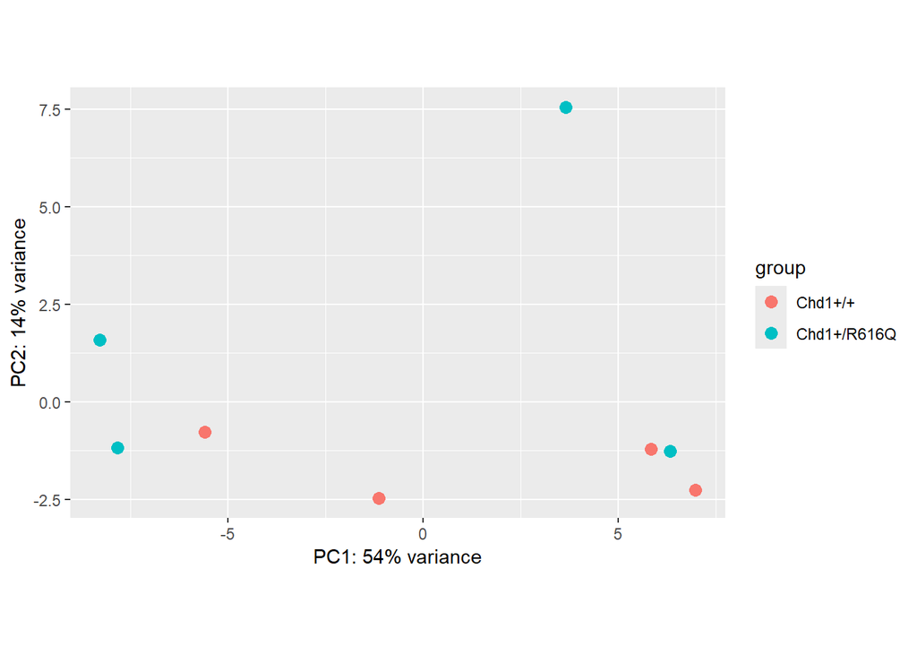

```r
vsd.genotype <- vst(dds.genotype, blind = FALSE)
plotPCA(vsd.genotype, intgroup = c("genotype"))
```

## 8.2 Sample distance heatmap

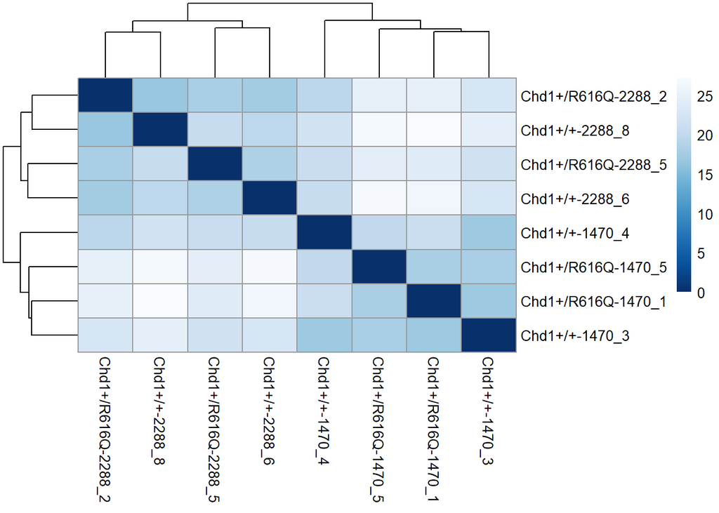

```r
sample.dists <- dist(t(assay(vsd.genotype)))
sample.dist.matrix <- as.matrix(sample.dists)

rownames(sample.dist.matrix) <- paste(vsd.genotype$genotype, vsd.genotype$embryo, sep = "-")
colnames(sample.dist.matrix) <- rownames(sample.dist.matrix)

heatmap.colors <- colorRampPalette(rev(brewer.pal(9, "Blues")))(255)

pheatmap(
  sample.dist.matrix,
  clustering_distance_rows = sample.dists,
  clustering_distance_cols = sample.dists,
  col = heatmap.colors
)
```

## 8.3 MA plot

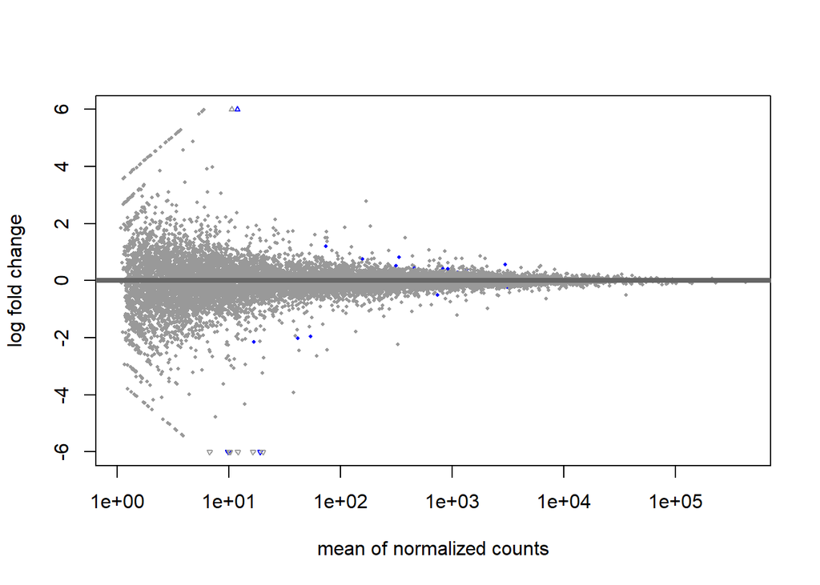

```r
plotMA(results(dds.genotype), ylim = c(-6, 6), lwd = 1)
```

## 8.4 Histogram of raw p-values

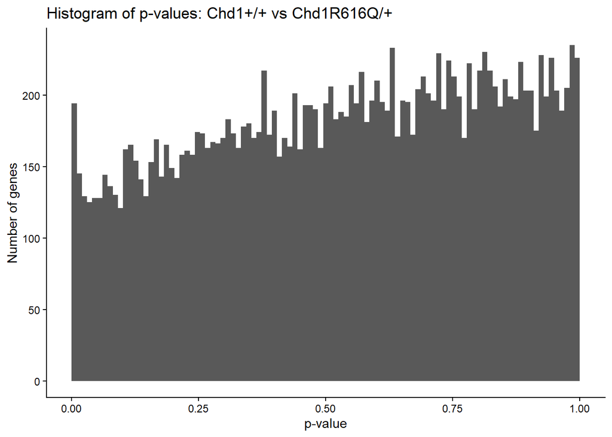

```r
ggplot(res.genotype, aes(x = pvalue)) +
  geom_histogram(bins = 100, boundary = 0) +
  theme_classic() +
  labs(
    title = "Histogram of p-values: Chd1+/+ vs Chd1R616Q/+",
    x = "p-value",
    y = "Number of genes"
  )
```

# 9 FDRtool correction

This section reproduces the corrected p-values and q-values used for ranking genes in the original analysis.

```
## Step 1... determine cutoff point
## Step 2... estimate parameters of null distribution and eta0
## Step 3... compute p-values and estimate empirical PDF/CDF
## Step 4... compute q-values and local fdr
## Step 5... prepare for plotting
```

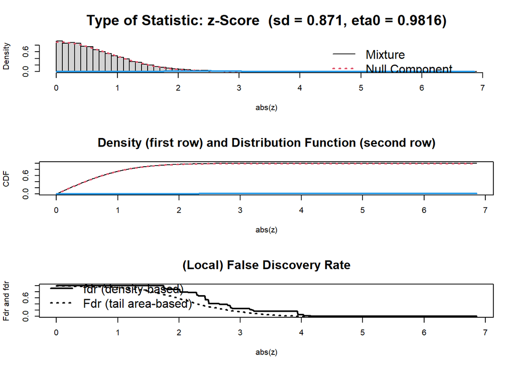

```r
res.genotype.filtered <- res.genotype %>%
  filter(!is.na(pvalue), !is.na(padj), !is.na(stat))

corrected.genotype <- fdrtool(
  res.genotype.filtered$stat,
  statistic = "normal",
  plot = TRUE
)
```

```r
corrected.genotype <- as.data.frame(corrected.genotype)
corrected.genotype$gene_id <- res.genotype.filtered$gene_id

res.genotype.filtered <- res.genotype.filtered %>%
  left_join(
    corrected.genotype %>% select(gene_id, cor.pval = pval, cor.qval = qval),
    by = "gene_id"
  ) %>%
  arrange(cor.pval)

res.genotype.all <- res.genotype.all %>%
  left_join(
    res.genotype.filtered %>% select(gene_id, cor.pval, cor.qval),
    by = "gene_id"
  ) %>%
  arrange(cor.pval)
```

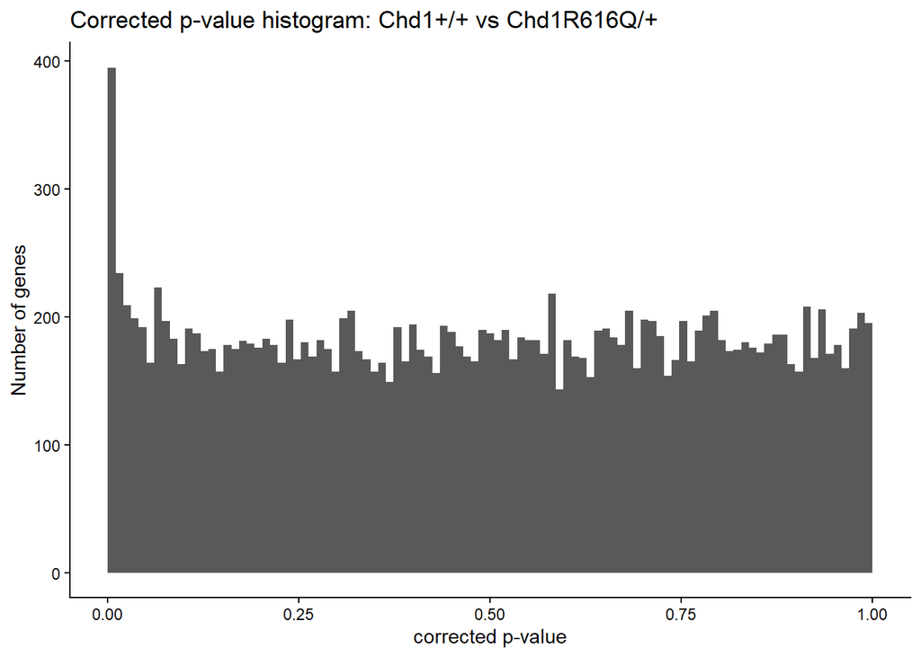

```r
ggplot(res.genotype.filtered, aes(x = cor.pval)) +
  geom_histogram(bins = 100, boundary = 0) +
  theme_classic() +
  labs(
    title = "Corrected p-value histogram: Chd1+/+ vs Chd1R616Q/+",
    x = "corrected p-value",
    y = "Number of genes"
  )
```

# 10 Export differential expression tables

```r
write.csv(
  res.genotype.all,
  "20231116_Chd1_NPC_genotype_DEGs_all.csv",
  row.names = FALSE
)

write.csv(
  res.genotype.all %>% filter(!is.na(cor.qval), cor.qval < 0.1),
  "20231116_Chd1_NPC_genotype_DEGs_corqval_0.1.csv",
  row.names = FALSE
)
```

# 11 Table of top genes

```r
res.genotype.all %>%
  select(gene, baseMean, log2FoldChange, lfcSE, stat, pvalue, padj, cor.pval, cor.qval) %>%
  slice_head(n = 20) %>%
  mutate(across(where(is.numeric), ~ signif(.x, 3))) %>%
  kable(format = "html", caption = "Top genes ranked by FDRtool-corrected p-value") %>%
  kable_styling(full_width = FALSE)
```

Top genes ranked by FDRtool-corrected p-value

| gene | baseMean | log2FoldChange | lfcSE | stat | pvalue | padj | cor.pval | cor.qval |
| --- | --- | --- | --- | --- | --- | --- | --- | --- |
| Zdhhc1 | 18.90 | -7.730 | 1.1300 | -6.86 | 0.00e+00 | 1.00e-07 | 0.00e+00 | 0.00e+00 |
| Trim66 | 333.00 | 0.822 | 0.1500 | 5.48 | 0.00e+00 | 3.86e-04 | 0.00e+00 | 2.80e-06 |
| Crocc | 459.00 | 0.442 | 0.0850 | 5.20 | 2.00e-07 | 1.20e-03 | 0.00e+00 | 1.38e-05 |
| Btbd9 | 737.00 | -0.508 | 0.1040 | -4.90 | 1.00e-06 | 4.29e-03 | 0.00e+00 | 7.31e-05 |
| Mmp14 | 2970.00 | 0.559 | 0.1150 | 4.86 | 1.20e-06 | 4.29e-03 | 0.00e+00 | 8.58e-05 |
| 9430008C03Rik | 315.00 | 0.514 | 0.1090 | 4.71 | 2.40e-06 | 7.36e-03 | 1.00e-07 | 1.82e-04 |
| Stard4 | 3070.00 | -0.239 | 0.0515 | -4.64 | 3.40e-06 | 8.87e-03 | 1.00e-07 | 2.46e-04 |
| Tulp3 | 3380.00 | 0.232 | 0.0523 | 4.43 | 9.50e-06 | 2.15e-02 | 4.00e-07 | 7.66e-04 |
| Grk4 | 73.80 | 1.190 | 0.2740 | 4.36 | 1.32e-05 | 2.66e-02 | 6.00e-07 | 1.04e-03 |
| Mapk10 | 828.00 | 0.407 | 0.0944 | 4.31 | 1.63e-05 | 2.96e-02 | 7.00e-07 | 1.25e-03 |
| Mlxipl | 16.80 | -2.150 | 0.5050 | -4.26 | 2.01e-05 | 3.31e-02 | 1.00e-06 | 1.46e-03 |
| Aqp4 | 11.90 | 6.970 | 1.6500 | 4.21 | 2.52e-05 | 3.45e-02 | 1.30e-06 | 1.70e-03 |
| Impg2 | 54.00 | -1.960 | 0.4650 | -4.21 | 2.58e-05 | 3.45e-02 | 1.40e-06 | 1.72e-03 |
| Upf1 | 908.00 | 0.421 | 0.1000 | 4.19 | 2.78e-05 | 3.45e-02 | 1.50e-06 | 1.80e-03 |
| Mtus2 | 41.40 | -2.020 | 0.4820 | -4.19 | 2.85e-05 | 3.45e-02 | 1.50e-06 | 1.82e-03 |
| Exoc3l4 | 9.82 | -6.780 | 1.6300 | -4.16 | 3.18e-05 | 3.61e-02 | 1.80e-06 | 1.97e-03 |
| Inpp5b | 1350.00 | 0.390 | 0.0966 | 4.04 | 5.39e-05 | 5.59e-02 | 3.50e-06 | 3.52e-03 |
| Srgap1 | 1110.00 | 0.283 | 0.0702 | 4.03 | 5.54e-05 | 5.59e-02 | 3.70e-06 | 3.62e-03 |
| Tspan11 | 157.00 | 0.754 | 0.1920 | 3.94 | 8.25e-05 | 7.88e-02 | 6.20e-06 | 5.76e-03 |
| Sobp | 564.00 | 0.358 | 0.0999 | 3.59 | 3.31e-04 | 3.01e-01 | 3.76e-05 | 2.99e-02 |

# 12 Top p-value decile genes

The manuscript used the genes with the top 10% most significant p-values to avoid missing biologically relevant changes when the stringent DEG list was modest.

```r
res.genotype.all <- res.genotype.all %>%
  filter(!is.na(cor.pval)) %>%
  mutate(pval.decile = ntile(cor.pval, 10))

genotype.top.decile <- res.genotype.all %>%
  filter(pval.decile == 1) %>%
  arrange(cor.pval)

nrow(genotype.top.decile)
```

```
## [1] 1808
```

```r
range(genotype.top.decile$cor.pval, na.rm = TRUE)
```

```
## [1] 3.330669e-15 8.038993e-02
```

```r
write.csv(
  genotype.top.decile,
  "20231116_Chd1_NPC_genotype_top_pvalue_decile.csv",
  row.names = FALSE
)
```

# 13 Enrichment analysis input

The exported top-decile gene list can be used for GO/KEGG overrepresentation analysis using a tool such as Metascape, clusterProfiler, WebGestalt, or g:Profiler.

```r
write.table(
  genotype.top.decile$gene,
  "20231116_Chd1_NPC_genotype_top_pvalue_decile_genes.txt",
  quote = FALSE,
  row.names = FALSE,
  col.names = FALSE
)
```

# 14 Oxytocin pathway genes

Genes plotted for the oxytocin signaling pathway:

- `Oxtr`
- `Gnaq`
- `Ptgs2`
- `Prkcg`
- `Rhoa`
- `Eef2k`

```r
# Use gene symbols as rownames for plotCounts.
dds.symbol <- dds.genotype
symbol.map <- gene.annotation$SYMBOL[match(rownames(dds.symbol), gene.annotation$GENEID)]
keep.symbol <- !is.na(symbol.map) & !duplicated(symbol.map)
dds.symbol <- dds.symbol[keep.symbol, ]
rownames(dds.symbol) <- symbol.map[keep.symbol]

plot_counts_for_gene <- function(gene) {
  plotCounts(
    dds.symbol,
    gene = gene,
    intgroup = c("genotype"),
    returnData = TRUE
  ) %>%
    mutate(gene = gene)
}
```

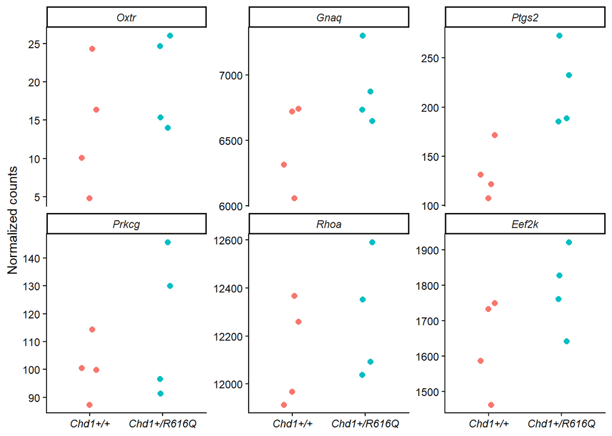

```r
oxytocin.genes <- c("Oxtr", "Gnaq", "Ptgs2", "Prkcg", "Rhoa", "Eef2k")

oxytocin.counts <- bind_rows(lapply(oxytocin.genes, plot_counts_for_gene))
oxytocin.counts$gene <- factor(oxytocin.counts$gene, levels = oxytocin.genes)

ggplot(oxytocin.counts, aes(x = genotype, y = count, colour = genotype)) +
  geom_point(position = position_jitter(width = 0.12, height = 0), size = 2) +
  facet_wrap(~ gene, scales = "free_y") +
  theme_classic() +
  theme(
    legend.position = "none",
    strip.text = element_text(face = "italic"),
    axis.text.x = element_text(face = "italic")
  ) +
  labs(
    x = NULL,
    y = "Normalized counts"
  )
```

# 15 Gene-length analysis

This analysis tests whether genes in the most significant p-value decile are longer than the remaining detected genes.

```r
mouse.genes <- genes(txdb) %>%
  as.data.frame()

# Remove duplicate column names, if present
mouse.genes <- mouse.genes[, !duplicated(names(mouse.genes))]

# Rename the TxDb width column
mouse.genes <- mouse.genes %>%
  dplyr::rename(gene_width = width)

# Add Ensembl gene IDs and gene symbols
mouse.genes$gene_id <- rownames(mouse.genes)

mouse.genes$gene <- gene.annotation$SYMBOL[
  match(mouse.genes$gene_id, gene.annotation$GENEID)
]

# Join gene lengths to the genotype DESeq2 results
res.length <- res.genotype.all %>%
  dplyr::left_join(
    mouse.genes %>% dplyr::select(gene, gene_width),
    by = "gene"
  ) %>%
  dplyr::filter(!is.na(gene_width), !is.na(cor.pval)) %>%
  dplyr::mutate(
    pval.decile = dplyr::ntile(cor.pval, 10),
    pval.group = ifelse(pval.decile == 1, "Top decile", "Other detected genes")
  )
```

```r
gene.length.summary <- res.length %>%
  dplyr::group_by(pval.decile) %>%
  dplyr::summarise(
    mean_length = mean(gene_width, na.rm = TRUE),
    median_length = median(gene_width, na.rm = TRUE),
    n = dplyr::n(),
    .groups = "drop"
  )

gene.length.summary
```

```
## # A tibble: 10 × 4
##    pval.decile mean_length median_length     n
##          <int>       <dbl>         <dbl> <int>
##  1           1      68443.        24242   1810
##  2           2      54545.        20290.  1810
##  3           3      52683.        19876   1809
##  4           4      51384.        20512   1809
##  5           5      50560.        18040   1809
##  6           6      49864.        18919   1809
##  7           7      46928.        18141   1809
##  8           8      48112.        17631   1809
##  9           9      48767.        18164   1809
## 10          10      42718.        17514   1809
```

```r
write.csv(
  gene.length.summary,
  "20231116_Chd1_NPC_genotype_gene_length_by_pvalue_decile.csv",
  row.names = FALSE
)
```

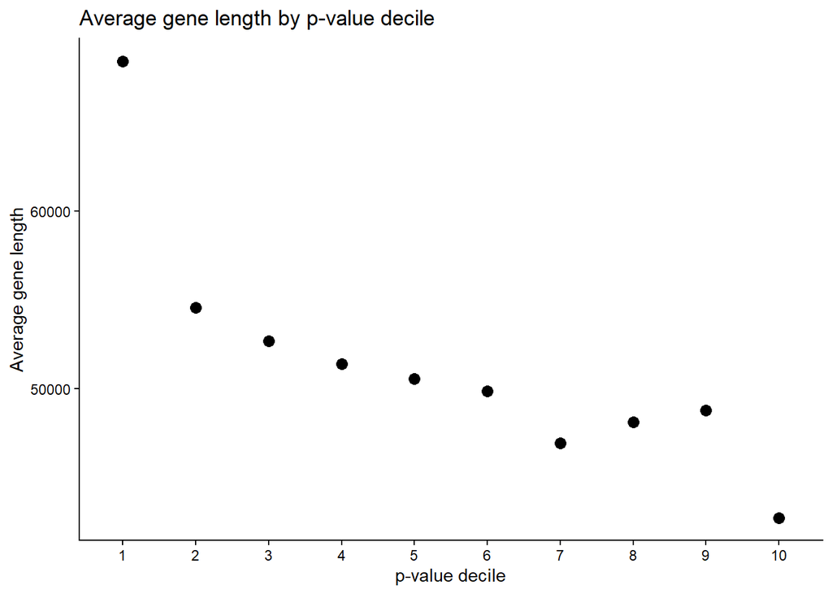

```r
ggplot(gene.length.summary, aes(x = factor(pval.decile), y = mean_length)) +
  geom_point(size = 3) +
  theme_classic() +
  labs(
    x = "p-value decile",
    y = "Average gene length",
    title = "Average gene length by p-value decile"
  )
```

```r
group.top <- res.length$gene_width[
  res.length$pval.group == "Top decile"
]

group.other <- res.length$gene_width[
  res.length$pval.group == "Other detected genes"
]

gene.length.test <- t.test(group.top, group.other, var.equal = FALSE)
gene.length.test
```

```
##
##  Welch Two Sample t-test
##
## data:  group.top and group.other
## t = 4.689, df = 1964.9, p-value = 2.934e-06
## alternative hypothesis: true difference in means is not equal to 0
## 95 percent confidence interval:
##  11015.94 26855.81
## sample estimates:
## mean of x mean of y
##  68442.98  49507.10
```

```r
eta2 <- gene.length.test$statistic^2 /
  (gene.length.test$statistic^2 + gene.length.test$parameter)

cohens.d <- 2 * sqrt(eta2 / (1 - eta2))
cohens.d
```

```
##         t
## 0.2115621
```

# 16 Comparison with unrelated NPC RNA-seq dataset

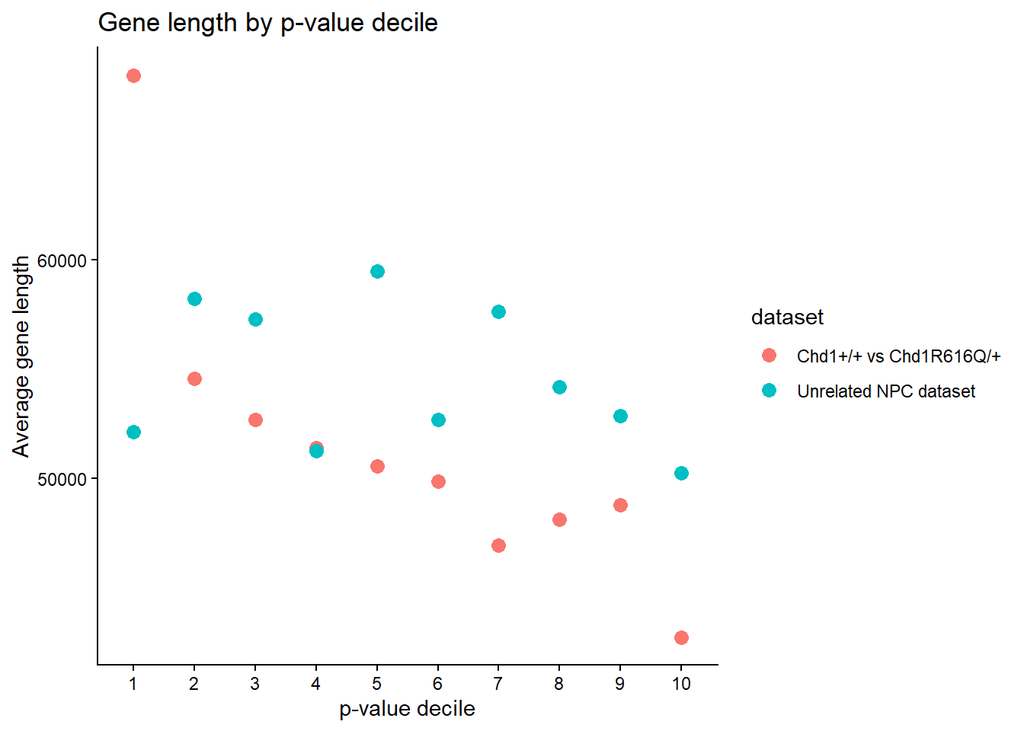

```r
temp <- read.csv("temp_mNPC_all_detected_genes_DEseq.csv")

# Expected columns include gene and pvalue.
temp <- temp %>%
  dplyr::rename(cor.pval = pvalue) %>%
  dplyr::left_join(
    mouse.genes %>% dplyr::select(gene, gene_width),
    by = "gene"
  ) %>%
  dplyr::filter(!is.na(gene_width), !is.na(cor.pval)) %>%
  dplyr::mutate(
    pval.decile = dplyr::ntile(cor.pval, 10),
    pval.group = ifelse(pval.decile == 1, "Top decile", "Other detected genes")
  )

temp.length.summary <- temp %>%
  dplyr::group_by(pval.decile) %>%
  dplyr::summarise(
    mean_length = mean(gene_width, na.rm = TRUE),
    median_length = median(gene_width, na.rm = TRUE),
    n = dplyr::n(),
    .groups = "drop"
  )

combined.length.summary <- dplyr::bind_rows(
  gene.length.summary %>%
    dplyr::mutate(dataset = "Chd1+/+ vs Chd1R616Q/+"),
  temp.length.summary %>%
    dplyr::mutate(dataset = "Unrelated NPC dataset")
)

ggplot(combined.length.summary, aes(
  x = factor(pval.decile),
  y = mean_length,
  colour = dataset
)) +
  geom_point(size = 3) +
  theme_classic() +
  labs(
    x = "p-value decile",
    y = "Average gene length",
    title = "Gene length by p-value decile"
  )
```

```r
temp.test <- t.test(
  temp$gene_width[temp$pval.group == "Top decile"],
  temp$gene_width[temp$pval.group == "Other detected genes"],
  var.equal = FALSE
)

temp.test
```

```
##
##  Welch Two Sample t-test
##
## data:  temp$gene_width[temp$pval.group == "Top decile"] and temp$gene_width[temp$pval.group == "Other detected genes"]
## t = -0.99911, df = 2092.8, p-value = 0.3179
## alternative hypothesis: true difference in means is not equal to 0
## 95 percent confidence interval:
##  -8128.997  2641.695
## sample estimates:
## mean of x mean of y
##  52117.02  54860.67
```

```r
eta2.temp <- temp.test$statistic^2 /
  (temp.test$statistic^2 + temp.test$parameter)

cohens.d.temp <- 2 * sqrt(eta2.temp / (1 - eta2.temp))
cohens.d.temp
```

```
##          t
## 0.04367943
```

# 17 Re-plotting webGestalt results

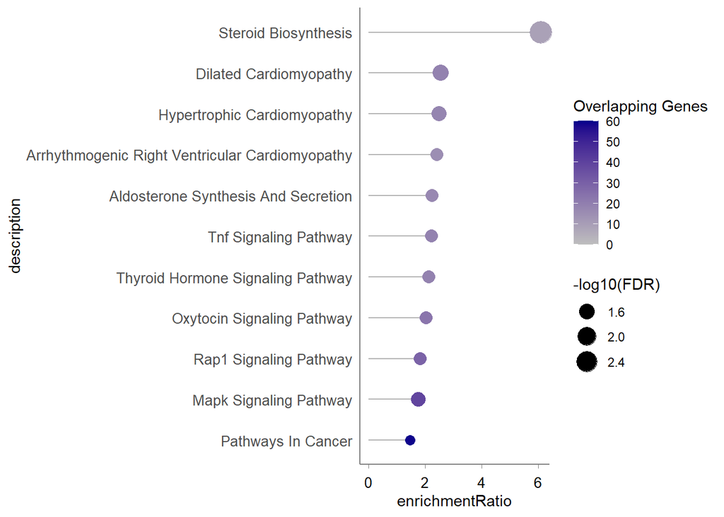

```r
library(stringr)

webGestaltPlot <- function(webgestalt_results) {
    # Function to capitalize the first letter of each category
    capitalize_first <- function(x) {
      str_to_title(x)  # Converts only the first letter to uppercase
    }
    # Sort data by enrichmentRatio for better visualization
    # Transform data
    webgestalt_results <- webgestalt_results %>%
      arrange(enrichmentRatio) %>%  # Sort by enrichment for better order
      mutate(
        description = factor(capitalize_first(description),
                             levels = capitalize_first(description)),  # Capitalize first letter
        logFDR = -log10(FDR)  # Transform FDR for better scaling
      )
    # Ensure min and max are different
    min_overlap <- floor(min(webgestalt_results$overlap) / 10) * 10
    # Round down to nearest 10
    max_overlap <- ceiling(max(webgestalt_results$overlap) / 10) * 10
    # Round up to nearest 10

    # If min and max are the same, add +10 to max to ensure at least two breakpoints
    if (min_overlap == max_overlap) {
      max_overlap <- min_overlap + 10
    }
    limit_values <- c(
        floor(min(webgestalt_results$overlap) / 10) * 10,
        # Round down to nearest 10
        ceiling(max(webgestalt_results$overlap) / 10) * 10
        # Round up to nearest 10
        )

    # Create dot plot
    wgp <-ggplot(webgestalt_results, aes(x = enrichmentRatio, y = description)) +

      # Add lines connecting labels to dots
      geom_segment(aes(xend = 0, yend = description),
                   color = "gray70", size = 0.5) +

      # Add dots with new aesthetics
      geom_point(aes(size = logFDR, color = overlap)) +

      # Define color scale from white to dark blue
      scale_color_gradient(low = "grey", high = "darkblue",
                           name = "Overlapping Genes",
                           #breaks = break_values,
                           # Ensures values like 10, 20, 30...
                           #labels = c(break_values)
                           # Forces whole numbers
                           limits = limit_values
                           ) +
      # Adjust size scale to reduce dramatic size differences
      scale_size_continuous(range = c(3, 7), name = "-log10(FDR)") +  # Adjust min/max size
      # Remove gridlines and improve appearance
      theme_minimal() +
      theme(
        panel.grid.major = element_blank(),  # Remove major gridlines
        panel.grid.minor = element_blank(),  # Remove minor gridlines
        axis.text.y = element_text(size = 10),  # Improve y-axis text readability
        axis.text.x = element_text(size = 10, colour = "black"),
        legend.position = "right"
      ) +

      theme(
        axis.line.x = element_line(color = "gray50", size = 0.5),
        axis.line.y = element_line(color = "gray50", size = 0.5),
        axis.ticks.x = element_line(color = "gray50",
                                    size = 0.3),  # Small gray tick marks on x-axis
        axis.ticks.length.x = unit(3, "pt")  # Adjust tick length (smaller ticks)
      ) +

      # Improve labels
     # labs(
      #  x = "Enrichment Score (Ratio)",
       # y = "Functional Category",
        #title = "WebGestalt Over-Representation Analysis",
      #  size = "-log10(FDR)"
      #) +

     coord_cartesian(clip = "off")
    return(wgp)
}
kegg_resGen <- read.delim("20231120_WebGestalt/Project_wg_result1724849897_KEGG_pathway_genotype_DEGs/enrichment_results_wg_result1724850072.txt",sep = "\t", header = TRUE)
kegg_resGen_plot <- webGestaltPlot(kegg_resGen)
kegg_resGen_plot
```

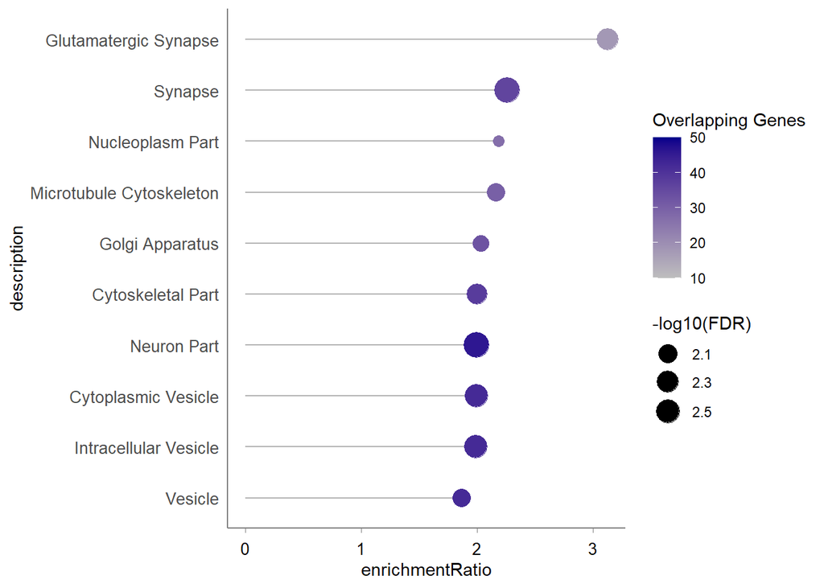

```r
ggsave(file = "Genotype_KEGG_OR_webGestalt.pdf", height = 3, width = 7, pointsize = 8, device = cairo_pdf)

overlap_cellcomp <- read.delim("20231120_WebGestalt/Project_wg_result1700473070_Cell_compartment/enrichment_results_wg_result1700473070.txt",sep = "\t", header = TRUE)
overlap_cellcomp_plot <- webGestaltPlot(overlap_cellcomp)
overlap_cellcomp_plot
```

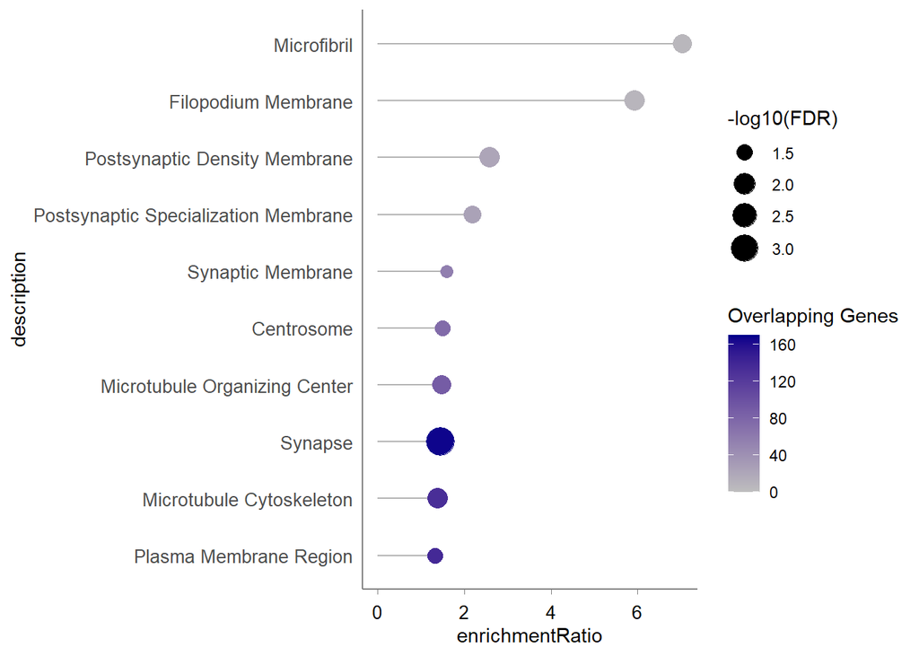

```r
ggsave(file = "Overlap_cellCompa_OR_webGestalt.pdf", height = 3, width = 5, pointsize = 8, device = cairo_pdf)

cellComp_genotype <- read.delim("20231120_WebGestalt/Project_wg_result1724849278_Cell_component_genotypeDEGS_top10%/enrichment_results_wg_result1724849278.txt", sep = "\t", header = TRUE)
cellComp_genotype_plot <- webGestaltPlot(cellComp_genotype)
cellComp_genotype_plot
```

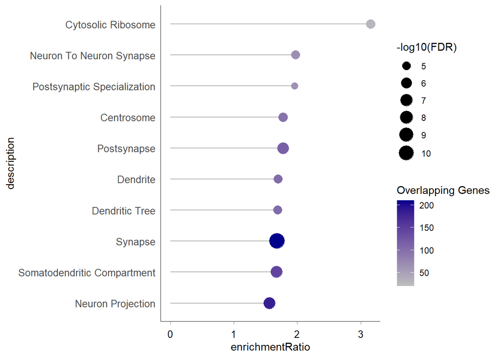

```r
ggsave(file = "Genotype_CellComp_OR_webGestalt.pdf", height = 3, width = 7, pointsize = 8, device = cairo_pdf)

cellComp_DHT <- read.delim("20231120_WebGestalt/Project_wg_result1724849278_Cell_component_DHT_DEGS_top10%/enrichment_results_wg_result1724849822.txt",  sep = "\t", header = TRUE)
cellComp_DHT_plot <- webGestaltPlot(cellComp_DHT)
cellComp_DHT_plot
```

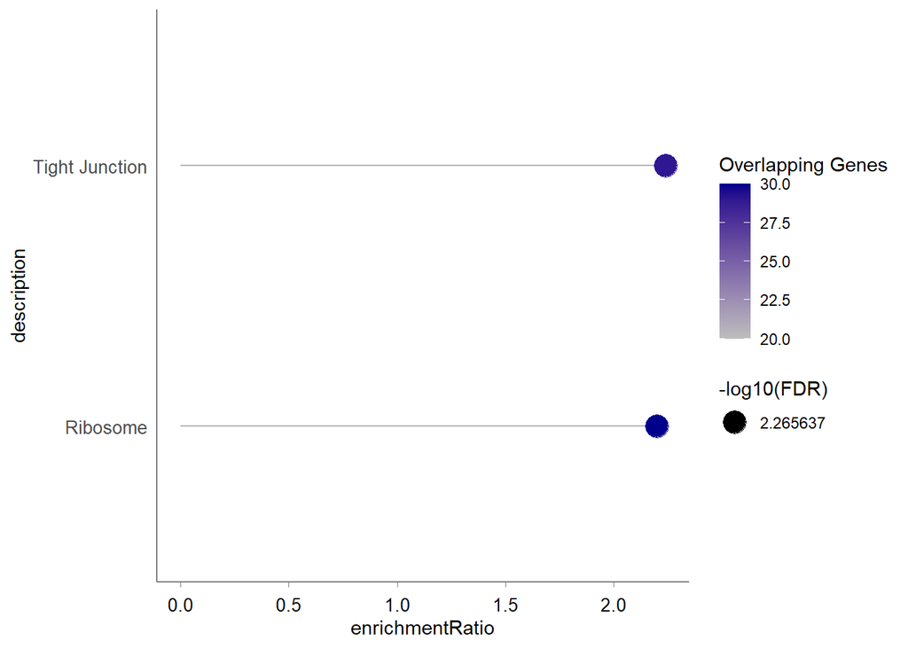

```r
ggsave(file = "DHT_CellComp_OR_webGestalt.pdf", height = 3, width = 5, pointsize = 8, device = cairo_pdf)

KEGG_DHT <- read.delim("20231120_WebGestalt/Project_wg_result1724849897_KEGG_pathway_DHT_DEGs/enrichment_results_wg_result1724849897.txt", sep = "\t", header = TRUE)
KEGG_DHT_plot <- webGestaltPlot(KEGG_DHT)
KEGG_DHT_plot
```

```r
ggsave(file = "DHT_KEGG_OR_webGestalt.pdf", height = 2, width = 3.5, pointsize = 8, device = cairo_pdf)
```

```
## R Under development (unstable) (2024-11-18 r87347 ucrt)
## Platform: x86_64-w64-mingw32/x64
## Running under: Windows 11 x64 (build 26200)
##
## Matrix products: default
##
##
## locale:
## [1] LC_COLLATE=English_Australia.utf8  LC_CTYPE=English_Australia.utf8
## [3] LC_MONETARY=English_Australia.utf8 LC_NUMERIC=C
## [5] LC_TIME=English_Australia.utf8
##
## time zone: Atlantic/Reykjavik
## tzcode source: internal
##
```

[output cut: 64 more lines]